# Pactical Machine Learning Prroject

Apostolos Lekkas

8/10/2020

## Overview

#Using devices such as Jawbone Up, Nike FuelBand, and Fitbit it is now possible to collect a large amount of data about personal activity relatively inexpensively. These type of devices are part of the quantified self movement – a group of enthusiasts who take measurements about themselves regularly to improve their health, to find patterns in their behavior, or because they are tech geeks. One thing that people regularly do is quantify how much of a particular activity they do, but they rarely quantify how well they do it. In this project, your goal will be to use data from accelerometers on the belt, forearm, arm, and dumbell of 6 participants. They were asked to perform barbell lifts correctly and incorrectly in 5 different ways. More information is available from the website here: http://web.archive.org/web/20161224072740/http:/groupware.les.inf.puc-rio.br/har (see the section on the Weight Lifting Exercise Dataset).

#The goal of this project is to predict the manner in which the participants did the aforementioned exercise. This is the “classe” variable in the training set. I will build a machine learning algorithm to apply to the available data and predict 20 different test cases.

#The data for this project can be found in this source: http://web.archive.org/web/20161224072740/http:/groupware.les.inf.puc-rio.br/har.

## Data Preparation

```r
#First I load the libraries to be used for the analysis.
set.seed(333)
library(knitr)
library(caret)
```

```r
library(rpart)
library(rpart.plot)
library(rattle)
library(randomForest)
library(corrplot)
library(gbm)
#I download data.
UrlTrain <- "https://d396qusza40orc.cloudfront.net/predmachlearn/pml-training.csv"
UrlTest  <- "https://d396qusza40orc.cloudfront.net/predmachlearn/pml-testing.csv"
training <- read.csv(url(UrlTrain))
testing  <- read.csv(url(UrlTest))

#I create partitions within data.
inTrain  <- createDataPartition(training$classe, p=0.7, list=FALSE)
TrainSet <- training[inTrain, ]
TestSet  <- training[-inTrain, ]
dim(TrainSet)
```

```
## [1] 13737   160
```

```r
dim(TestSet)
```

```
## [1] 5885  160
```

```r
#Training and testing datasets consist of 160 variables. In the next step I will remove variables with plenty of NAs, near zero variance variables, as well as identification variables (columns 1 to 5). The cleaned datasets will then be ready for analysis.
NZV <- nearZeroVar(TrainSet)
TrainSet <- TrainSet[, -NZV]
TestSet  <- TestSet[, -NZV]
dim(TrainSet)
```

```
## [1] 13737   104
```

```r
dim(TestSet)
```

```
## [1] 5885  104
```

```r
AllNA    <- sapply(TrainSet, function(x) mean(is.na(x))) > 0.95
TrainSet <- TrainSet[, AllNA==FALSE]
TestSet  <- TestSet[, AllNA==FALSE]
dim(TrainSet)
```

```
## [1] 13737    59
```

```r
dim(TestSet)
```

```
## [1] 5885   59
```

```r
TrainSet <- TrainSet[, -(1:5)]
TestSet  <- TestSet[, -(1:5)]
dim(TrainSet)
```

```
## [1] 13737    54
```

```r
dim(TestSet)
```

```
## [1] 5885   54
```

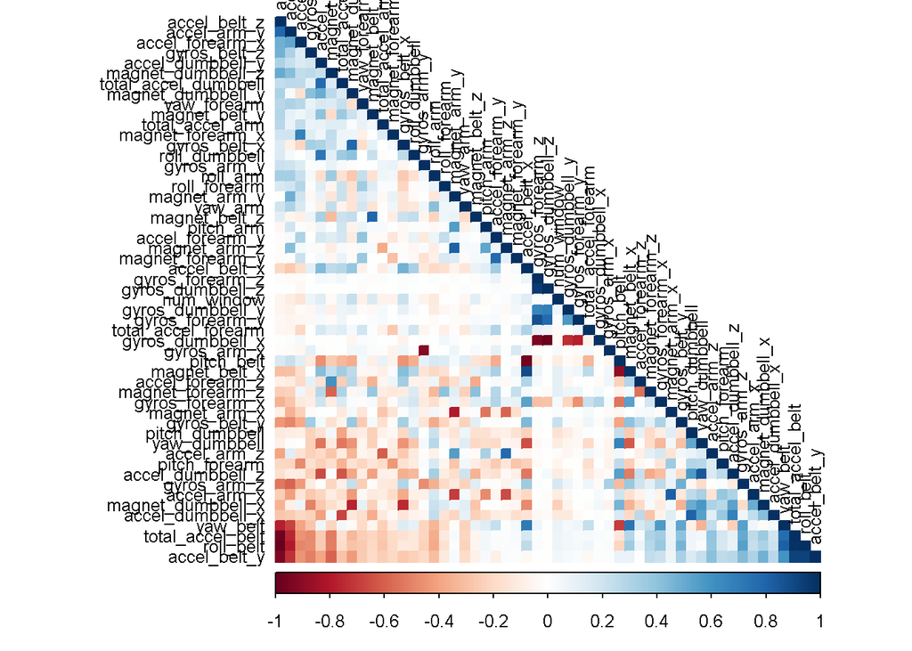

```r
#We can see that the remaining variables in the datasets are 54. First, we need to perform correlation tests.
corMatrix <- cor(TrainSet[, -54])
corrplot(corMatrix, order = "FPC", method = "color", type = "lower",
         tl.cex = 0.8, tl.col = rgb(0, 0, 0))
```

## Model Building

#I will apply Random Forests, Decision Trees and Generalized Boosted Models as three different Machine Learning algorithms to model the regressions in the training dataset. The model with the best fit (higher accuracy on the test dataset) will be used to predict the test cases.

#1) Random Forests

```r
#Model fit.
controlRF <- trainControl(method="cv", number=3, verboseIter=FALSE)
modFitRandForest <- train(classe ~ ., data=TrainSet, method="rf",
                          trControl=controlRF)
modFitRandForest$finalModel
```

```
##
## Call:
##  randomForest(x = x, y = y, mtry = param$mtry)
##                Type of random forest: classification
##                      Number of trees: 500
## No. of variables tried at each split: 27
##
##         OOB estimate of  error rate: 0.23%
## Confusion matrix:
##      A    B    C    D    E  class.error
## A 3904    2    0    0    0 0.0005120328
## B    8 2647    2    1    0 0.0041384500
## C    0    4 2392    0    0 0.0016694491
## D    0    0    7 2244    1 0.0035523979
## E    0    0    0    7 2518 0.0027722772
```

```r
#Model apply.
predictRandForest <- predict(modFitRandForest, newdata=TestSet)
confMatRandForest <- confusionMatrix(predictRandForest, as.factor(TestSet$classe))
confMatRandForest
```

```
## Confusion Matrix and Statistics
##
##           Reference
## Prediction    A    B    C    D    E
##          A 1674    3    0    0    0
##          B    0 1134    3    0    2
##          C    0    2 1023    3    0
##          D    0    0    0  961   10
##          E    0    0    0    0 1070
##
## Overall Statistics
##
##                Accuracy : 0.9961
##                  95% CI : (0.9941, 0.9975)
##     No Information Rate : 0.2845
##     P-Value [Acc > NIR] : < 2.2e-16
##
##                   Kappa : 0.9951
##
##  Mcnemar's Test P-Value : NA
##
## Statistics by Class:
##
##                      Class: A Class: B Class: C Class: D Class: E
## Sensitivity            1.0000   0.9956   0.9971   0.9969   0.9889
## Specificity            0.9993   0.9989   0.9990   0.9980   1.0000
## Pos Pred Value         0.9982   0.9956   0.9951   0.9897   1.0000
## Neg Pred Value         1.0000   0.9989   0.9994   0.9994   0.9975
## Prevalence             0.2845   0.1935   0.1743   0.1638   0.1839
## Detection Rate         0.2845   0.1927   0.1738   0.1633   0.1818
## Detection Prevalence   0.2850   0.1935   0.1747   0.1650   0.1818
## Balanced Accuracy      0.9996   0.9973   0.9980   0.9974   0.9945
```

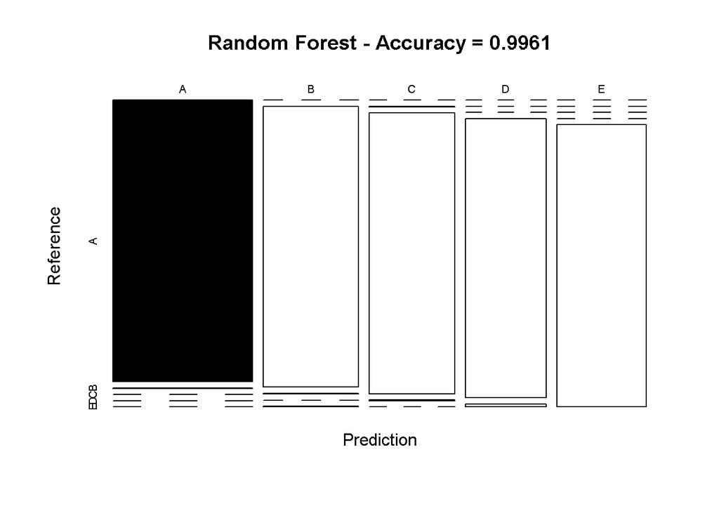

```r
#Plot matrix to visualise the results.
plot(confMatRandForest$table, col = confMatRandForest$byClass,
     main = paste("Random Forest - Accuracy =",
                  round(confMatRandForest$overall['Accuracy'], 4)))
```

#2) Decision Trees

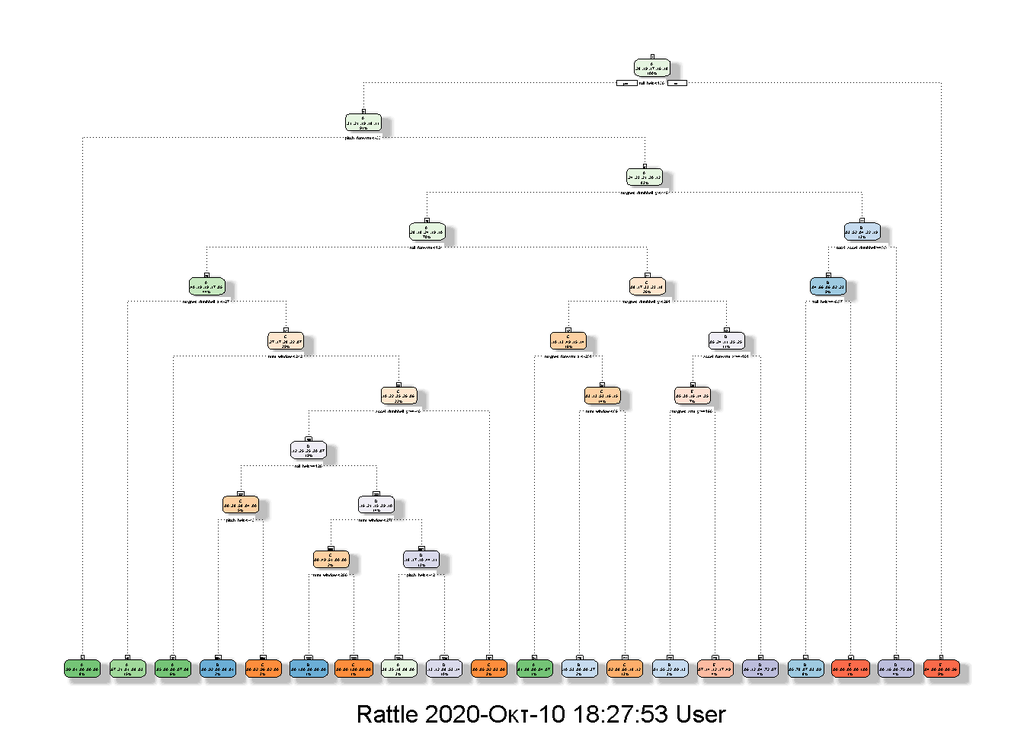

```r
#Model fit on train dataset.
modFitDecTree <- rpart(classe ~ ., data=TrainSet, method="class")
fancyRpartPlot(modFitDecTree)
```

```r
#Model apply to test dataset.
predictDecTree <- predict(modFitDecTree, newdata=TestSet, type="class")
confMatDecTree <- confusionMatrix(predictDecTree, as.factor(TestSet$classe))
confMatDecTree
```

```
## Confusion Matrix and Statistics
##
##           Reference
## Prediction    A    B    C    D    E
##          A 1472  244   38  106   71
##          B   40  633   83   38   91
##          C   18   77  822  132   73
##          D   95  150   59  639  142
##          E   49   35   24   49  705
##
## Overall Statistics
##
##                Accuracy : 0.7257
##                  95% CI : (0.7142, 0.7371)
##     No Information Rate : 0.2845
##     P-Value [Acc > NIR] : < 2.2e-16
##
##                   Kappa : 0.6516
##
##  Mcnemar's Test P-Value : < 2.2e-16
##
## Statistics by Class:
##
##                      Class: A Class: B Class: C Class: D Class: E
## Sensitivity            0.8793   0.5558   0.8012   0.6629   0.6516
## Specificity            0.8910   0.9469   0.9383   0.9094   0.9673
## Pos Pred Value         0.7623   0.7153   0.7326   0.5889   0.8179
## Neg Pred Value         0.9489   0.8988   0.9572   0.9323   0.9249
## Prevalence             0.2845   0.1935   0.1743   0.1638   0.1839
## Detection Rate         0.2501   0.1076   0.1397   0.1086   0.1198
## Detection Prevalence   0.3281   0.1504   0.1907   0.1844   0.1465
## Balanced Accuracy      0.8852   0.7513   0.8697   0.7861   0.8094
```

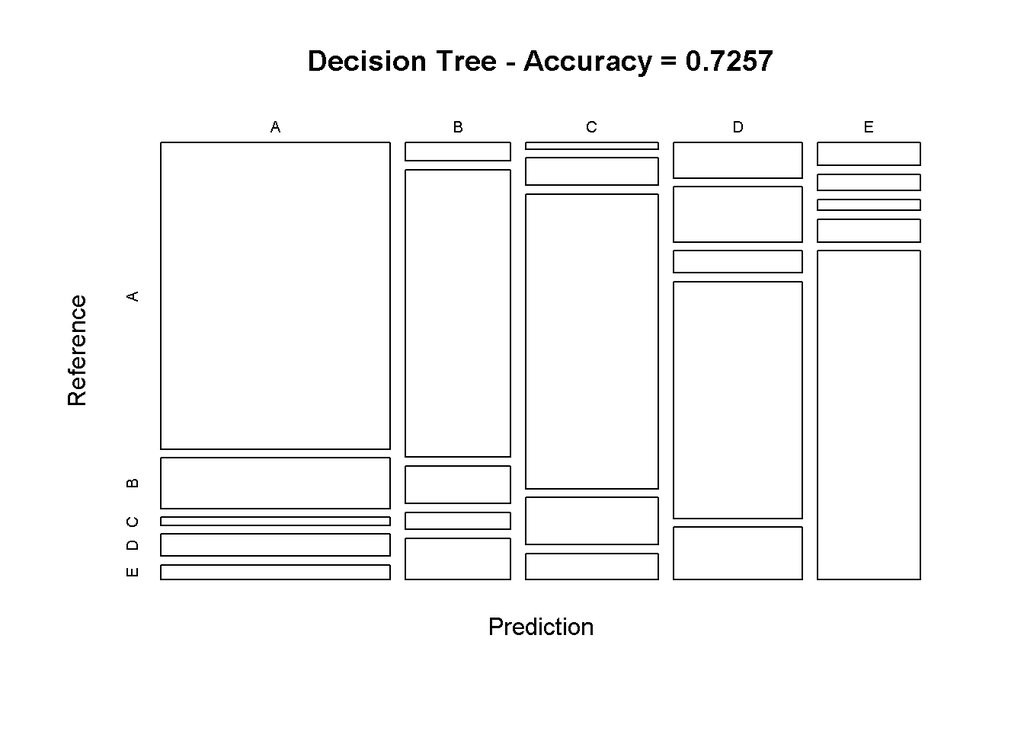

```r
#Plot matrix to visualise the results.
plot(confMatDecTree$table, col = confMatDecTree$byClass,
     main = paste("Decision Tree - Accuracy =",
                  round(confMatDecTree$overall['Accuracy'], 4)))
```

#3) Generalized Boosted Model

```r
#Model fit on train dataset.
controlGBM <- trainControl(method = "repeatedcv", number = 5, repeats = 1)
modFitGBM  <- train(classe ~ ., data=TrainSet, method = "gbm",
                    trControl = controlGBM, verbose = FALSE)
modFitGBM$finalModel
```

```
## A gradient boosted model with multinomial loss function.
## 150 iterations were performed.
## There were 53 predictors of which 53 had non-zero influence.
```

```r
#Model apply to test dataset.
predictGBM <- predict(modFitGBM, newdata=TestSet)
confMatGBM <- confusionMatrix(predictGBM, as.factor(TestSet$classe))
confMatGBM
```

```
## Confusion Matrix and Statistics
##
##           Reference
## Prediction    A    B    C    D    E
##          A 1669   15    0    0    0
##          B    5 1104    9    4    8
##          C    0   20 1016   16    3
##          D    0    0    1  944   18
##          E    0    0    0    0 1053
##
## Overall Statistics
##
##                Accuracy : 0.9832
##                  95% CI : (0.9796, 0.9863)
##     No Information Rate : 0.2845
##     P-Value [Acc > NIR] : < 2.2e-16
##
##                   Kappa : 0.9787
##
##  Mcnemar's Test P-Value : NA
##
## Statistics by Class:
##
##                      Class: A Class: B Class: C Class: D Class: E
## Sensitivity            0.9970   0.9693   0.9903   0.9793   0.9732
## Specificity            0.9964   0.9945   0.9920   0.9961   1.0000
## Pos Pred Value         0.9911   0.9770   0.9630   0.9803   1.0000
## Neg Pred Value         0.9988   0.9926   0.9979   0.9959   0.9940
## Prevalence             0.2845   0.1935   0.1743   0.1638   0.1839
## Detection Rate         0.2836   0.1876   0.1726   0.1604   0.1789
## Detection Prevalence   0.2862   0.1920   0.1793   0.1636   0.1789
## Balanced Accuracy      0.9967   0.9819   0.9911   0.9877   0.9866
```

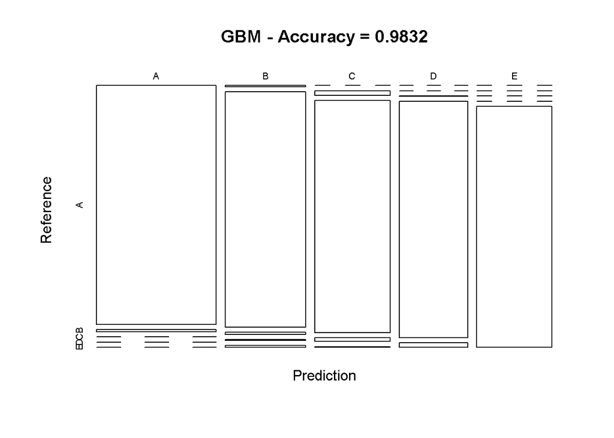

```r
#Plot matrix to visualise the results.
plot(confMatGBM$table, col = confMatGBM$byClass,
     main = paste("GBM - Accuracy =", round(confMatGBM$overall['Accuracy'], 4)))
```

##Conclusion #We can conclude that the model with the best fit on our dataset was the Random Forest model and therefore it will be used to predict the test cases.

```r
predictTEST <- predict(modFitRandForest, newdata=testing)
predictTEST
```

```
##  [1] B A B A A E D B A A B C B A E E A B B B
## Levels: A B C D E
```